# Revisión de comandos

Categoría cálculo de la cobertura

David Mateo Murillo Proyecto: paquetes de R para estimar y comparar la riqueza: revisión para una correcta elección

Jul-2024

# Comandos relacionados con el cálculo de la cobertura

Después de haber hecho la revisión de los 15 paquetes, a continuación se listan los comandos relacionados con esta temática y el paquete al que pertenecen.

```
# A tibble: 6 × 4
  comando     categoria otros paquetes
  <chr>       <chr>     <chr> <chr>
1 coverage    C2        <NA>  BAT
2 Coverage    C2        C1    entropart
3 depth_cov   C2        D1    hilldiv
4 DataInfo    C2        <NA>  iNEXT
5 Diversity   C2        D1    SpadeR
6 ChaoSpecies D1        C2    SpadeR
```

## Carga de las librerías respectivas

```r
# Librerias y funciones
library(BAT)
library(entropart)
library(hilldiv)
library(iNEXT)
library(SpadeR)

source('https://raw.githubusercontent.com/paguzmang/funciones/master/describe_diver.R')
```

## Cargue de los datos

Los datos utilizados son 1453 registros de artrópodos pertenecientes a 133 familias, y tres morfotipos llevados hasta orden. (Sin embargo, de aquí en adelante se mencionarán como 136 familias) que fueron registrados por el *Grupo de Monitoreo de la Biodiversidad de la Secretaría Distrital de Ambiente* como resultado del monitoreo entre 2021-2022 de cuatro Parques Distritales Ecológicos de Montaña: Entre Nubes (ENGA y ENJR), La Serranía de Zuqué (ZUQ), Soratama (SOR) y Mirador de los Nevados (NEV). Estos registros fueron publicados a través del SiB Colombia como un DwC-A, bajo una licencia [CC-BY-NC](https://creativecommons.org/licenses/by-nc/4.0/legalcode).

> Ramírez Martínez N M, Rodríguez Ortíz J, Urrego Salinas M D P, Gonzalez Aguas C C, García concha J H (2023): Artrópodos de los Parques Distritales Ecológicos de Montaña. v1.4. Secretaría Distrital de Ambiente. Dataset/Occurrence. https://doi.org/10.15472/cwrg3e

El DwC fue filtrado y organizado de forma que la primera columna indica el evento de muestreo (que contiene información del Parque Distrital respectivo); el resto de columnas corresponden a las familias de artrópodos observadas en el estudio, y los eventos de muestreo están en filas. Esto obedece a que consideramos que uno de los formatos más empleados al momento de tomar registros en campo es el de *sitios en fila y especies en columna*. El archivo `datos_sitio_fila.rds` se puede descargar [aquí](https://github.com/Sleiven/Paquetes-Riqueza/raw/Prueba_datos/datos_sitio_fila.rds).

El script con el cual se hizo la modificación desde el archivo .txt del DwC está [disponible](https://github.com/Sleiven/Paquetes-Riqueza/blob/main/Occurrence_DwC_to_sitiosFila.R), por lo que puede utilizarse para cualquier otro tipo de evento de muestreo publicado a través del SiB Colombia, lo que le dará más visibilidad a la información que es publicada y acompañada por el EC-SiB.

```
#> Se importan los datos
```

```r
ensamblaje <- readRDS("datos_sitio_fila.rds")
```

```r
# Se muestra cantidad de filas y columnas (Sitio de muestreo + 136 familias)
# También se muestra parte de la tabla
dim(ensamblaje); ensamblaje[1:5, 1:5]
```

```
[1] 1276  137
```

```
# A tibble: 5 × 5
  eventID     Melyridae Araneidae Erebidae Cosmetidae
  <chr>           <int>     <int>    <int>      <int>
1 ENGA_12_RED         1         0        0          0
2 ENGA_12_RED         0         1        0          0
3 ENGA_12_RED         0         1        0          0
4 SOR_7_MM            0         0        1          0
5 SOR_2_TP            0         0        0          1
```

```r
# Se quita primera columna para obtener valores basicos de todo el ensamblaje
(describe_ensa <- ensamblaje %>%
                    select(-eventID) %>%
                      colSums() %>%
                        describe_diver())
```

```
     N Riq f1 f2        H      q1        H1
1 4944 136 15 19 3.888783 48.8514 0.7915848
```

Entonces este ensamblaje obtuvo 4944 individuos, con una riqueza de 136 familias, donde 15 de ellas se observaron una vez; 19 se observaron dos veces.

## `DataInfo` {iNEXT}

Este comando acepta *vectores*, *matriz*, *dataframe* o *lista* con *especies en fila y sitios en columnas* ya sea con datos de **abundancia** basada en individuos `datatype = 'abundance'`, o con **frecuencias de incidencia** en unidades de muestra `datatype = 'incidence_freq'` (Si se usa este valor, la primera entrada debe ser el número total de unidades de muestreo), o **incidencia de especies x unidades de muestreo** `datatype = 'incidence_raw'`. (Con la salvedad de que esta es solo para matrices o dataframe).

Considerando los datos ejemplo, es **necesario acomodarla** al formato familias x sitio, cuyo procedimiento se muestra a continuación:

```r
# 1a. Juntar todas las filas que pertenecen al mismo sitio (cuatro Parques Distritales)
ensamblaje_unif <- ensamblaje %>%

  #> Crear nueva columna con las dos primeras letras de cada sitio para unificarlos
  mutate(sitio = substr(eventID, start = 1, stop = 2)) %>%

  #> Eliminar la columna con el nombre amplio de sitio
  select(sitio, everything(), -eventID) %>%

  #> Suman las abundancias de un mismo Parque Distrital
  group_by(sitio) %>% summarise(across(everything(), sum))

# Muestra de la tabla
print('tabla intermedia')
ensamblaje_unif[, 1:6]

# 1b. Ajustar tabla a familias x sitio
artropodos <- ensamblaje_unif[,-1] %>% t()
colnames(artropodos) <- ensamblaje_unif$sitio

# Muestra de la tabla final
print('tabla final')
head(artropodos)
```

```
[1] "tabla intermedia"
# A tibble: 4 × 6
  sitio Melyridae Araneidae Erebidae Cosmetidae Blattidae
  <chr>     <int>     <int>    <int>      <int>     <int>
1 EN           13        51        1         58        19
2 NE            0        13        0          0         2
3 SO           28         2        1         34         7
4 ZU            3        23        1         88         0
[1] "tabla final"
                EN NE SO ZU
Melyridae       13  0 28  3
Araneidae       51 13  2 23
Erebidae         1  0  1  1
Cosmetidae      58  0 34 88
Blattidae       19  2  7  0
Sclerosomatidae  5  0  6  3
```

Entonces, cada columna es uno de los Parques Distritales Ecológicos de Montaña: Entre Nubes (*EN*), Mirador de los Nevados (*NE*), Soratama (*SO*) y La Serranía de Zuqué (*ZU*).

### Referencia

Como referencia, se muestran los valores de cantidad de individuos (N) y riqueza observada (Riq) en cada uno de los sitios.

```r
(ref <- apply(X = artropodos, MARGIN = 2, FUN = describe_diver))
```

```
$EN
     N Riq f1 f2        H       q1      H1
1 2378 102 15  8 3.786373 44.09616 0.81868

$NE
    N Riq f1 f2        H       q1        H1
1 969  61 10 12 2.800044 16.44537 0.6811311

$SO
    N Riq f1 f2        H       q1        H1
1 603  58 17  6 3.059246 21.31148 0.7534266

$ZU
    N Riq f1 f2        H       q1        H1
1 994  87 20 15 3.605278 36.79191 0.8072889
```

Para obtener el valor de cobertura con `DataInfo()` solo se necesita ingresar los datos y el tipo de datos en **`datatype`**. En caso de que sean datos de abundancia (como en este ejemplo) se puede omitir el argumento.

```r
DataInfo(artropodos)
```

```
  Assemblage    n S.obs     SC f1 f2 f3 f4 f5 f6 f7 f8 f9 f10
1         EN 2378   102 0.9937 15  8  8  6  4  3  2  3  4   4
2         NE  969    61 0.9897 10 12  4  3  4  2  1  3  3   1
3         SO  603    58 0.9718 17  6  6  5  2  3  4  1  3   1
4         ZU  994    87 0.9799 20 15 10  5  6  0  2  0  3   4
```

El formato de entrega es un dataframe que muestra la información “básica” para cada sitio, entre ellos la cantidad de individuos (n); el valor de cobertura (SC); junto con la riqueza observada (S.obs) y frecuencias observadas (e.g. f1 cantidad de singletons). Por estas razones lo veo como un comando muy **sencillo para obtener de forma rápida la cobertura de diferentes sitios**. Una desventaja es que **no se menciona explícitamente cuál es la fórmula** utilizada para la cobertura.

Por último, si se **utiliza `iNEXT` junto con `ggiNEXT`** se puede obtener una gráfica de cómo cambia la completitud de la muestra conforme aumenta la cantidad de individuos o muestras, por defecto hasta el doble de la cantidad registrada en cada sitio:

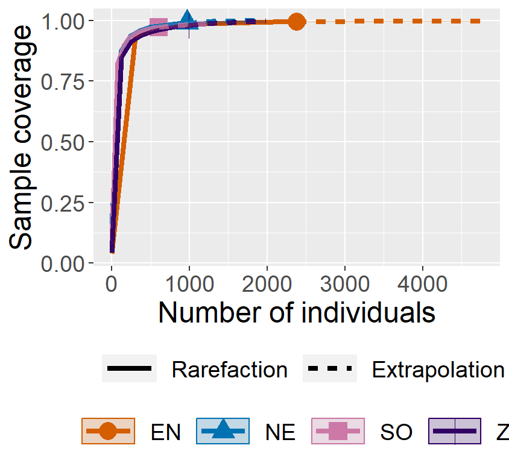

```r
# 1. Se utiliza el comando iNEXT, 98% intervalo de confianza, 100 aleatorizaciones bootstrap, y 20 "pasos"
set.seed(23)
valores <- iNEXT(artropodos, q = 0, conf = 0.98, nboot = 100, knots = 20)

# 2. Se pasa por ggiNEXT() o plot() con type = 2
library(ggplot2)
ggiNEXT(valores, type = 2)
```

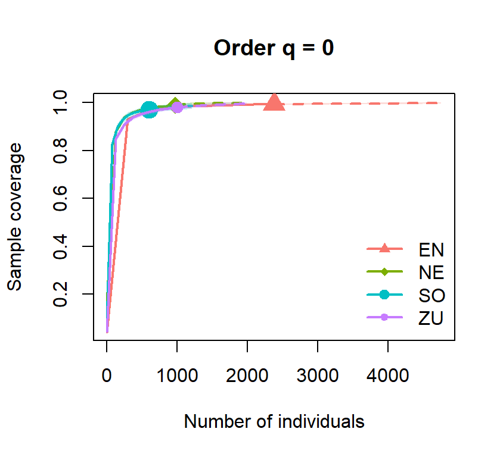

```r
plot(valores, type = 2)
```

La última ventaja con `ggiNEXT()` es que el argumento `facet.var = 'Assemblage'` hace un gráfico para cada uno de los sitios

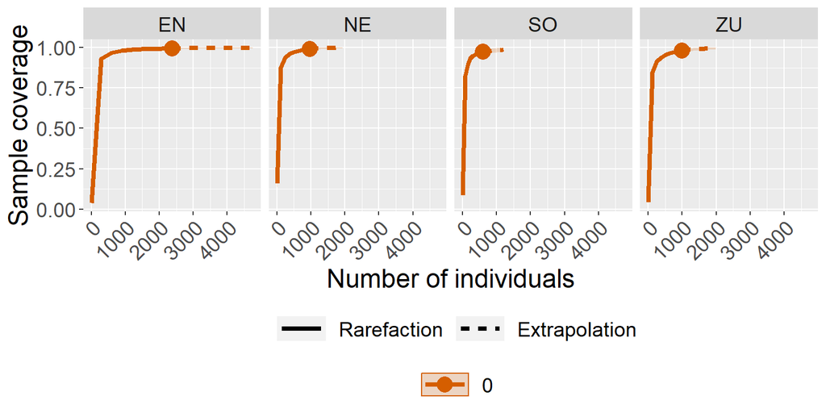

```r
ggiNEXT(valores, type = 2, facet.var = 'Assemblage') +
  theme(axis.text.x = element_text(angle = 45, hjust = 1))
```

## `depth_cov` {hilldiv}

Este comando solo maneja dos argumentos: `abund`, que es un *vector, matriz o dataframes* que tiene *especies en filas*, con los valores de la **abundancia relativa**; y **`qvalue`**, que representa el valor q deseado (para este contexto, solo se utilizaría el q = 0).

Por tanto, si utilizamos los datos de referencia, organizados en sitios (filas) x familias (columnas), **tendríamos que hacer dos pasos**. Primero: las mismas modificaciones hechas para el comando anterior. Segundo, volver relativa las abundancias. A continuación se muestra todo el proceso.

```r
# 1a. Ajustar los nombres de los sitios

  #> Juntar todas las filas que pertenecen al mismo sitio (cuatro Parques Distritales)
  ensamblaje_unif <- ensamblaje %>%

  #> Crear nueva columna con las dos primeras letras de cada sitio para unificarlos
  mutate(sitio = substr(eventID, start = 1, stop = 2)) %>%

  #> Eliminar la columna con el nombre amplio de sitio
  select(sitio, everything(), -eventID) %>%

  #> Suman las abundancias de un mismo Parque Distrital
  group_by(sitio) %>% summarise(across(everything(), sum))

# 1b. Ajustar tabla a especies x sitio
artropodos <- ensamblaje_unif[,-1] %>% t()

colnames(artropodos) <- ensamblaje_unif$sitio

# 2. Relativizar los registros
artropodos_rel <- artropodos/rowSums(artropodos)
```

Una vez hecho esto, ya se puede utilizar el comando:

```r
# Uso del comando con q = 0
depth_cov(artropodos_rel, q = 0)
```

```
      Depth Observed Estimated Coverage
EN 61.90232      102    270.24    37.74
NE 22.06306       61     95.37    63.96
SO 16.53132       58     67.40    86.06
ZU 35.50331       87    203.62    42.73
```

```r
# Uso del comando de los datos no relativos
depth_cov(artropodos, q = 0)
```

```
   Depth Observed Estimated Coverage
EN  2378      102    116.06    87.89
NE   969       61     65.16    93.61
SO   603       58     82.04    70.69
ZU   994       87    100.32    86.72
```

Al parecer la estimación que utilizan es la de *Chao, A. & Jost, L. (2015)* Estimating diversity and entropy profiles via discovery rates of new species. Methods in Ecology and Evolution, 6, 873-882. ([doi](https://besjournals.onlinelibrary.wiley.com/doi/full/10.1111/2041-210X.12349)), **Pero no se menciona la fórmula utilizada para la cobertura**

Por otro lado, ¿utilizar entonces las abundancias relativas, como se recomienda, o dejar las abundancias, como encontré más comprensibles los resultados? En septiembre del 2023, tengo una nota que “no tendría sentido si, habiendo bastantes singletons, se tiene una cobertura elevada”. A continuación se imprimen los valores de referencia

```r
ref
```

```
$EN
     N Riq f1 f2        H       q1      H1
1 2378 102 15  8 3.786373 44.09616 0.81868

$NE
    N Riq f1 f2        H       q1        H1
1 969  61 10 12 2.800044 16.44537 0.6811311

$SO
    N Riq f1 f2        H       q1        H1
1 603  58 17  6 3.059246 21.31148 0.7534266

$ZU
    N Riq f1 f2        H       q1        H1
1 994  87 20 15 3.605278 36.79191 0.8072889
```

En este caso, el sitio con menos singletons es NE (10 vs 15, 17 o 20), y cuando NO se usaron los valores relativos, este es el que tiene mayor cobertura; mientras que con los valores relativos, quien tuvo mejor cobertura fue SO, el cual tiene 17 singletons. Por lo que **me inclinaría por utilizar las abundancias sin los valores relativos**

Entonces, creo que es relativamente sencillo de utilizar (solo utiliza dos argumentos, o uno si no se relativiza las abundancias), pero el uso de las abundancias relativas vs abundancias no es clara. Además, no menciona que pueda usar incidencias.

## `coverage` {BAT}

Este toma una *matriz de sitios (filas) x especies* con valores de **abundancia**. En ese sentido, corresponde con el formato utilizado en los datos de referencia, salvo que hay que ajustar los nombres de los sitios y volverlo matriz

```r
# 1. Ajustar los nombres de los sitios

  # Juntar todas las filas que pertenecen al mismo sitio (cuatro parques)
  ensamblaje_unif <- ensamblaje %>%

  # Crear nueva columna con las dos primeras letras de cada sitio para unificarlos
  mutate(sitio = substr(eventID, start = 1, stop = 2)) %>%

  # se elimina la columna con el nombre amplio de sitio
  select(sitio, everything(), -eventID) %>%

  # se suman las abundancias de un mismo sitio
  group_by(sitio) %>% summarise(across(everything(), sum))

# 2. Convertir en matriz (sin la primera columna)
sitios <- ensamblaje_unif[,1]
artropodos_mat <- as.matrix(ensamblaje_unif[,-1])
rownames(artropodos_mat) <- sitios[[1]]

# Se imprime una muestra
artropodos_mat[,1:8]
```

```
   Melyridae Araneidae Erebidae Cosmetidae Blattidae Sclerosomatidae
EN        13        51        1         58        19               5
NE         0        13        0          0         2               0
SO        28         2        1         34         7               6
ZU         3        23        1         88         0               3
   Scarabaeidae Formicidae
EN           19        117
NE            4        361
SO            8        109
ZU            0         11
```

NOTA: fue necesario quitar la primera columna antes de volverlo matriz, porque de lo contrario, convertía todos los registros en texto, lo cual no es admitido por el comando.

Con esto ya se puede ingresar al comando

```r
coverage(artropodos_mat)
```

```
   Melyridae
EN 0.9936950
NE 0.9897056
SO 0.9718406
ZU 0.9799096
```

Ahí se entrega el resultado de la cobertura **para cada sitio** (ellos **citan que la formula que utilizan** es la de *Chao y Jost 2012* “coverage-based rarefaction and extrapolation”). Sin embargo, **algo que puede confundir** es que el resultado muestra el nombre de la primera columna de la matriz (en este caso, la familia Melyridae). A continuación se demuestra que **se puede ignorar**, porque si se altera el orden de las columnas, no se afecta el resultado.

```r
mat1 <- artropodos_mat[,sample.int(ncol(artropodos_mat))]
#>> sample.int toma un número (en este caso la cantidad de columnas de la matriz)
#>> y hace muestreo aleatorio sin reemplazo

mat2 <- artropodos_mat[,sample.int(ncol(artropodos_mat))]

mat3 <- artropodos_mat[,sample.int(ncol(artropodos_mat))]

cbind(coverage(artropodos_mat), coverage(mat1), coverage(mat2), coverage(mat3))
```

```
   Melyridae Cantharidae Lauxaniidae Elateridae
EN 0.9936950   0.9936950   0.9936950  0.9936950
NE 0.9897056   0.9897056   0.9897056  0.9897056
SO 0.9718406   0.9718406   0.9718406  0.9718406
ZU 0.9799096   0.9799096   0.9799096  0.9799096
```

Por tanto, es un comando que sirve para obtener la cobertura de múltiples sitios, que recibe el formato que se suele utilizar al tomar los registros en campo, y que se menciona cuál es la fórmula específica que utiliza.

## `Coverage` {entropart}

Este recibe un *vector* de **abundancias**, por lo que en el caso de los datos ejemplo, habrían dos opciones: o sumar todos los sitios y tomar la cobertura de todo el ensamblaje (lo que toma **un paso**), o sacar cada sitio para calcularle su cobertura (toma cuatro pasos por **cada uno**), . Para forma comparativa, se sumarán todos los sitios; pero también se mostrará un ejemplo de cómo obtener la cobertura de un solo sitio.

```r
# 1. Sumar todos los sitios

  ensamblaje_abund <- ensamblaje %>%

  # Quitar la columna con el identificador del sitio
  select(everything(), -eventID) %>%

  # se suman las abundancias
  summarise(across(everything(), sum))

# 2. Convertir en un vector
  vector_abund <- unlist(as.vector(ensamblaje_abund))
```

Con esto ya se puede utilizar el comando, junto con el argumento **`Estimator`** que permite especificar entre **cuatro fórmulas de cobertura**: `'ZhangHuang', 'Chao', 'Turing', 'Good'` (El valor por defecto es `'Best'`, que calcula la misma fórmula que `'ZhangHuang'`). También considerar que **se mencionan los artículos de donde se tomaron las fórmulas** el artículo de Good de 1953 para la formula “Turing”; el artículo de Chao y Shen, 2010, para el de “Chao” y el artículo de Zhang and Huang, 2007 para el “ZhangHuang”. Es decir, no se menciona fórmula para “Good”, pero se asumiría que se menciona en el artículo de Chao, Lee y Chen 1988, por descarte de las referencias que están.

```r
# Uso por defecto
Coverage(vector_abund) # Por defecto utiliza 'Best' que es igual a 'ZhangHuang'
```

```
ZhangHuang
 0.9969676
```

```r
# Uso con el argumento 'Chao'
Coverage(vector_abund, Estimator = "Chao")
```

```
     Chao
0.9969676
```

```r
# Comparar valores
sapply(X = c("Best", "Chao", "Turing", "Good"),
       FUN = function(x) Coverage(vector_abund, Estimator = x))
```

```
Best.ZhangHuang       Chao.Chao   Turing.Turing            Good
      0.9969676       0.9969676       0.9969660              NA
```

El comando también tiene el argumento `Level`, el cual permite colocar cualquier valor de abundancia (sea menor o mayor a la observada) y calcularía el valor de la cobertura interpolada o extrapolada. Sin embargo, aquí no se menciona porque hace parte de otra categoría de comandos.

Ahora, en caso de que se quiera usar el comando para un solo sitio, se haría el siguiente procedimiento:

```r
# 1. Ajustar los nombres de los sitios

  # Juntar todas las filas que pertenecen al mismo sitio (cuatro parques)
  ensamblaje_unif <- ensamblaje %>%

  # Crear nueva columna con las dos primeras letras de cada sitio para unificarlos
  mutate(sitio = substr(eventID, start = 1, stop = 2)) %>%

  # se elimina la columna con el nombre amplio de sitio
  select(sitio, everything(), -eventID) %>%

  # se suman las abundancias de un mismo sitio
  group_by(sitio) %>% summarise(across(everything(), sum))

# 2. Sacar el sitio de elección
abund_sitio <- ensamblaje_unif %>%  filter(sitio == "NE")

# 3. Convertir en vector (Quitando la columna del nombre)
vector_sitio <- abund_sitio[,-1] %>% as.vector() %>% unlist()

# 4. Usar en el comando
Coverage(vector_sitio, Estimator = "Chao")
```

```
     Chao
0.9897056
```

En caso de querer hacer una comparación por cada sitio, se puede hacer una función (se retomaría desde el punto 2 del chunk anterior)

```r
filtrar_sitio <- function(x){
  ensamblaje_unif %>%
    filter(sitio == x) %>%
    select(-sitio) %>%
    as.vector() %>%
    unlist()
}

sapply(X = c("EN", "NE", "ZU", "SO"),
       FUN = function(x) Coverage(filtrar_sitio(x), Estimator = "Chao"))
```

```
  EN.Chao   NE.Chao   ZU.Chao   SO.Chao
0.9936950 0.9897056 0.9799096 0.9718406
```

Y ya se reemplazaría cada uno de los estimadores.

Si bien toca hacer un poco más para sacar por cada sitio, le veo como bastante positivo que incluye más fórmulas, todas con su literatura.

## `Diversity` y `ChaoSpecies` {SpadeR}

Los comandos de este paquete reciben varios formatos, los cuales están explicados al principio del html dedicado a SpadeR (de los cinco tipos que maneja el paquete, éste los recibe todos). A modo de resumen, se manejan tanto abundancias como incidencias, todos organizados con especies en fila y comunidades en columna (aunque algunos solo reciben una sola comunidad).

En este caso, con los datos de ejemplo, hay que acomodarlo a familias x sitio y convertirlo en dataframe (aunque en el comando dice que también recibe matriz):

```r
# 1. Ajustar los nombres de los sitios

  # Juntar todas las filas que pertenecen al mismo sitio (cuatro parques)
  ensamblaje_unif <- ensamblaje %>%

  # Crear nueva columna con las dos primeras letras de cada sitio para unificarlos
  mutate(sitio = substr(eventID, start = 1, stop = 2)) %>%

  # se elimina la columna con el nombre amplio de sitio
  select(sitio, everything(), -eventID) %>%

  # se suman las abundancias de un mismo sitio
  group_by(sitio) %>% summarise(across(everything(), sum))

# 2. Ajustar tabla a especies x sitio
artropodos <- ensamblaje_unif[,-1] %>% t()

colnames(artropodos) <- ensamblaje_unif$sitio

# 3. Confirmar que queda como dataframe
artropodos_df <- as.data.frame(artropodos)
```

### Uso en `Diversity`

Ya con esto se puede insertar en el comando, llamando uno a uno la columna de cada sitio, y especificando en **`datatype`** que el formato es `'abundance'`. Además, se debe utilizar el argumento **`q`** el cual debe ser un vector de dos números, con los números de Hill que se quieren calcular (en este caso, nos interesa los resultados en 0).

NOTA: Dado que este es el mismo nombre que tiene un comando de `entropart`, entonces se debe especificar el paquete.

```r
SpadeR::Diversity(artropodos_df$NE, datatype = 'abundance', q = c(0,1))
```

```
(1) BASIC DATA INFORMATION:
                               Variable Value
    Sample size                       n   969
    Number of observed species        D    61
    Estimated sample coverage         C  0.99
    Estimated CV                     CV 2.968

(2) ESTIMATION OF SPECIES RICHNESS (DIVERSITY OF ORDER 0):

                             Estimate s.e. 95%Lower 95%Upper
    Chao1 (Chao, 1984)           65.2  3.5     62.0     78.7
    Chao1-bc                     64.5  3.1     61.8     76.6
    iChao1                       65.8  2.2     63.1     72.2
    ACE (Chao & Lee, 1992)       67.8  4.3     63.2     82.0
    ACE-1 (Chao & Lee, 1992)     69.1  5.3     63.5     87.1

        Descriptions of richness estimators (See Species Part)

(3a) SHANNON ENTROPY:

                        Estimate  s.e. 95%Lower 95%Upper
     MLE                   2.800 0.056    2.690    2.910
     Jackknife             2.839 0.056    2.728    2.949
     Chao & Shen           2.853 0.055    2.745    2.962
     Chao et al. (2013)    2.836 0.056    2.726    2.946

        MLE: empirical or observed entropy.
        Jackknife: see Zahl (1977).
        Chao & Shen: based on the Horvitz-Thompson estimator and sample coverage method; see Chao and Shen (2003).
        see Chao and Shen (2003).
        Chao et al. (2013): A nearly optimal estimator of Shannon entropy; see Chao et al. (2013).
        Estimated standard error is computed based on a bootstrap method.

(3b) SHANNON DIVERSITY (EXPONENTIAL OF SHANNON ENTROPY):

                        Estimate  s.e. 95%Lower 95%Upper
     MLE                  16.445 0.895   14.691   18.200
     Jackknife            17.091 0.931   15.267   18.915
     Chao & Shen          17.347 0.923   15.538   19.155
     Chao et al. (2013)   17.047 0.929   15.225   18.869
```

[output cut: 9 more lines]

```

(4b) SIMPSON DIVERSITY (INVERSE OF SIMPSON CONCENTRATION):

          Estimate    s.e. 95%Lower 95%Upper
     MVUE  6.28386 0.47150  5.35971  7.20801
     MLE   6.24978 0.46568  5.33705  7.16252

(5) CHAO AND JOST (2015) ESTIMATES OF HILL NUMBERS

       q ChaoJost 95%Lower 95%Upper Empirical 95%Lower 95%Upper
     1 0   65.162   52.945   77.379    61.000   56.514   65.486
     2 1   17.047   15.107   18.987    16.445   14.581   18.309

        ChaoJost: diversity profile estimator derived by Chao and Jost (2015).
        Empirical: maximum likelihood estimator (observed index).
```

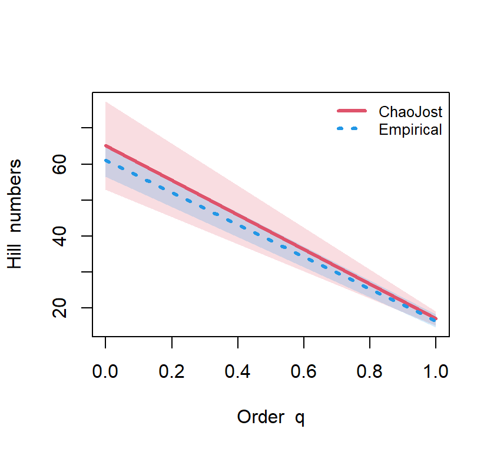

Como se puede observar, el resultado de este comando incluye siete secciones y un gráfico. En el marco de la estimación de cobertura, **nos interesa solo la primera sección**, pues incluye una estimación de la cobertura de la muestra. El resto de secciones, aunque muy bien organizadas, son estimaciones de riqueza (las cuales están en la categoría respectiva) e índices de diversidad.

La sección de interés se puede extraer de forma individual. A continuación se muestra para cada uno de los sitios

```r
sitios <- colnames(artropodos_df)
res <- vector()

for(x in 1:length(sitios)){
  res[x] <- SpadeR::Diversity(data = artropodos_df[x], datatype = "abundance", q = c(0,1))$Basic_data[3,2]
}
names(res) <- sitios

res
```

```
     EN      NE      SO      ZU
"0.994"  "0.99" "0.972"  "0.98"
```

Al observar este código veo que es **un poco arduo sacar los valores para cada sitio**, por lo que podría ser un punto negativo.

### Uso en `ChaoSpecies`

Aunque entre sus resultados se encuentran valores de cobertura (explicados a continuación), el comando pareciera estar enfocado en la estimación de la riqueza. Es por eso que dentro de sus argumentos se encuentra un **`k`**, el cual apunta a la teoría de dos estimadores (ACE e ICE) que establecen un punto de corte (cut-off) para separar las especies en dos grupos: las abundantes y las raras. Por ejemplo, si `k = 10` (como es el valor por defecto), entonces se considera que las especies raras son las vistas 10 o menos veces (mientras que si alguna especie se vio 11 veces o más, ya se considera abundante. Por lo que es un poco arbitrario).

Por ejemplo, en el sitio de Mirador de los Nevados (NE), tenemos las siguientes frecuencias:

```r
table(artropodos_df$NE)
```

```
  0   1   2   3   4   5   6   7   8   9  10  11  12  13  14  15  16  17  19  20
 75  10  12   4   3   4   2   1   3   3   1   1   1   2   1   1   2   1   1   1
 27  32  33  36  70  86 361
  1   1   1   1   1   1   1
```

10 especies fueron vistas 1 vez, 12 especies fueron vistas dos veces, y así sucesivamente. (las 75 especies “no vistas” es porque se vieron en los otros sitios del estudio) ¿Cómo definimos un punto de corte aquí? ¿son raras aquellas especies que vimos 9 veces, 7, 6?

Tomo el tiempo para explicar esto en este documento porque, este comando, además de entregar la estimación de la cobertura para todo el ensamblaje, **también entrega el estimado de cobertura para las especies raras**.

La **sintaxis** y formatos para este comando son **muy parecidos al anterior**.

```r
(CS_res <- ChaoSpecies(data = artropodos_df$NE, datatype = "abundance", k = 9))
```

```
(1) BASIC DATA INFORMATION:

                                         Variable Value
    Sample size                                 n   969
    Number of observed species                  D    61
    Coverage estimate for entire dataset        C  0.99
    CV for entire dataset                      CV 2.968
    Cut-off point                               k     9

                                                      Variable Value
    Number of observed individuals for rare group       n_rare   148
    Number of observed species for rare group           D_rare    42
    Estimate of the sample coverage for rare group      C_rare 0.932
    Estimate of CV for rare group in ACE               CV_rare 0.588
    Estimate of CV1 for rare group in ACE-1           CV1_rare 0.676
    Number of observed individuals for abundant group   n_abun   821
    Number of observed species for abundant group       D_abun    19

NULL


(2) SPECIES RICHNESS ESTIMATORS TABLE:

                              Estimate  s.e. 95%Lower 95%Upper
    Homogeneous Model           64.043 2.139   61.879   71.534
    Homogeneous (MLE)           61.000 0.003   61.000   61.006
    Chao1 (Chao, 1984)          65.162 3.541   61.980   78.676
    Chao1-bc                    64.458 3.104   61.766   76.603
    iChao1 (Chiu et al. 2014)   65.829 2.160   63.091   72.153
    ACE (Chao & Lee, 1992)      67.752 4.233   63.184   81.869
    ACE-1 (Chao & Lee, 1992)    68.940 5.238   63.444   86.791
    1st order jackknife         70.990 4.469   65.325   84.072
    2nd order jackknife         69.006 7.734   62.631  100.308


(3) DESCRIPTION OF ESTIMATORS/MODELS:

Homogeneous Model: This model assumes that all species have the same incidence or detection probabilities. See Eq. (3.2) of Lee and Chao (1994) or Eq. (12a) in Chao and Chiu (2016b).

Chao2 (Chao, 1987): This approach uses the frequencies of uniques and duplicates to estimate the number of undetected species; see Chao (1987) or Eq. (11a) in Chao and Chiu (2016b).

Chao2-bc: A bias-corrected form for the Chao2 estimator; see Chao (2005).

iChao2: An improved Chao2 estimator; see Chiu et al. (2014).

ICE (Incidence-based Coverage Estimator): A non-parametric estimator originally proposed by Lee and Chao (1994) in the context of capture-recapture data analysis. The observed species are separated as frequent and infrequent species groups; only data in the infrequent group are used to estimate the …

ICE-1: A modified ICE for highly-heterogeneous cases.

1st order jackknife: It uses the frequency of uniques to estimate the number of undetected species; see Burnham and Overton (1978).

2nd order jackknife: It uses the frequencies of uniques and duplicates to estimate the number of undetected species; see Burnham and Overton (1978).

95% Confidence interval: A log-transformation is used for all estimators so that the lower bound of the resulting interval is at least the number of observed species. See Chao (1987).
```

El resultado tiene tres secciones, pero para el cálculo de la cobertura nos interesa la primera.

```r
# Segmento del resultado de ChaoSpecies que nos interesa
CS_res[1]
```

```
$Basic_data_information
                                                      Variable Value
    Sample size                                              n   969
    Number of observed species                               D    61
    Coverage estimate for entire dataset                     C  0.99
    CV for entire dataset                                   CV 2.968
    Cut-off point                                            k     9
    Number of observed individuals for rare group       n_rare   148
    Number of observed species for rare group           D_rare    42
    Estimate of the sample coverage for rare group      C_rare 0.932
    Estimate of CV for rare group in ACE               CV_rare 0.588
    Estimate of CV1 for rare group in ACE-1           CV1_rare 0.676
    Number of observed individuals for abundant group   n_abun   821
    Number of observed species for abundant group       D_abun    19
```

Notar que primero entrega el valor de la cobertura de todo el ensamblaje (cuyo resultado es el mismo que el obtenido por el comando anterior), y luego muestra el valor de la cobertura para el grupo raro (junto con las especies y cantidad de individuos de cada grupo). A continuación se muestran los valores de referencia.

```r
# Comparación con descripcion basica de grupo "abundante"
describe_diver(artropodos_df[artropodos_df$NE > 9, "NE"])
```

```
    N Riq f1 f2        H       q1        H1
1 821  19  0  0 2.171107 8.767988 0.7373586
```

```r
# Descripcion basica de grupo "raro"
describe_diver(artropodos_df[artropodos_df$NE <= 9, "NE"])
```

```
    N Riq f1 f2        H       q1        H1
1 148  42 10 12 3.490474 32.80148 0.9338636
```

Sin duda, es el único comando que incluye este resultado. Y si bien es interesante, **no conozco literatura sobre la cobertura de las especies raras**, que mencione por ejemplo “si tienes una cobertura de especies raras mayor a X porcentaje, entonces estás más seguro de que se caracterizó el ensamblaje”. Además, está el aspecto que **definir ese punto de corte es ambiguo**, por lo que puede que no sea un valor agregado en todos los casos.

# Comparación de los comandos analizados

De los seis comandos revisados (`DataInfo`, `depth_cov`, `coverage`, `Coverage`, `Diversity` y `ChaoSpecies`), repartidos entre cinco paquetes (`iNEXT`, `hilldiv`, `BAT`, `entropart`, cada uno con uno, y `SpadeR` con dos), resalto los siguientes rasgos a comparar:

|  | iNEXT DataInfo | hilldiv depth_cov | BAT coverage | entropart Coverage | SpadeR Diversity | SpadeR ChaoSpecies |
| --- | --- | --- | --- | --- | --- | --- |
| Acepta datos de abundancia | SI | SI | SI | SI | SI | SI |
| Acepta datos de incidencia | SI | NO | NO | NO | SI | SI |
| Pasos desde los datos referencia hasta el input | 1 | 2 | 1 | 4 | 2 | 2 |
| Cantidad de argumentos | 2 | 2 | 1 | 2 | 3 | 3 |
| Permite varios sitios | SI | SI | SI | NO | NO | NO |
| Cantidad de fórmulas de cobertura disponibles | 1 | 1 | 1 | 4 | 1 | 1 |
| Tiene referencia a la(s) formula(s) | NO | NO | SI | SI | NO | NO |

¿Qué puedo decir? Diría que por tener menos pasos, permitir varios sitios, y tener la fórmula del cálculo de cobertura que utiliza, **recomendaría `coverage`{BAT}** Aunque su punto negativo es la posible confusión por el nombre del resultado, se explicó que esto se puede omitir. Sin embargo, es muy llamativo la aproximación de `Coverage` {entropart} de ofrecer varias fórmulas (de las cuales también tiene las referencias), aunque esto implique mayor cantidad de pasos para tener el valor para múltiples sitios.

Pero, en caso de que se esté tratando **con incidencias** (o tanto incidencias como abundancias), ninguno de estos dos puede utilizarse. En ese caso, **recomendaría `DataInfo` {iNEXT}** pues tiene menos pasos y argumentos, y puede graficarse con otros comandos del paquete, con la única desventaja de no informar el cálculo que utiliza. (Notar que las otras dos opciones que manejas incidencia, `Diversity` y `ChaoSpecies`, tampoco tiene las referencias y es más tedioso emplearlo para varios sitios). Finalmente, la aparente ventaja de `ChaoSpecies` de ofrecer la cobertura del grupo poco abundante, tomaría mucho más valor si en la literatura se menciona al respecto.